# CVD Analysis

# Coversheet

[figure not shown]

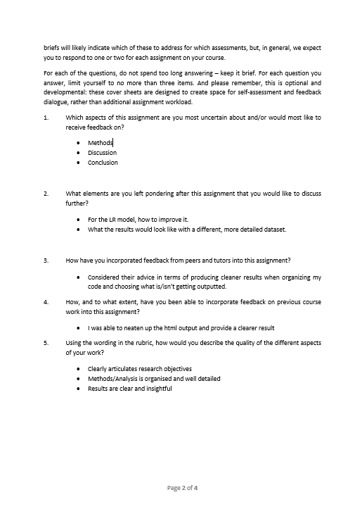

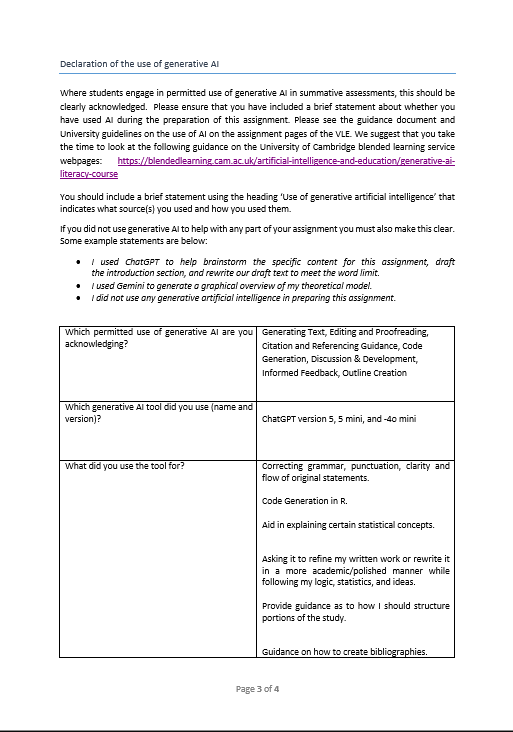

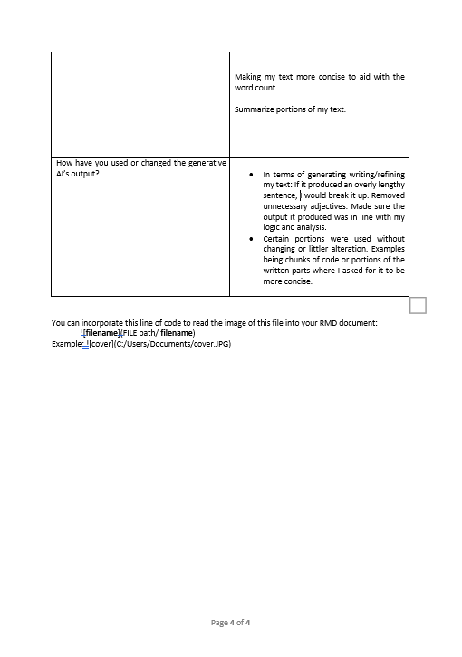

# Abstract

Cardiovascular disease (CVD) continues to be the leading cause of death globally, encompassing conditions such as coronary heart disease, stroke, and heart failure. Multiple risk factors for CVD—such as age, cholesterol, glucose, blood pressure, and gender—have been established; however, less is known about their combined effects and the role of pulse pressure, an indicator of arterial stiffness. This study used an open-source dataset consisting of 70,000 adult patients and 13 features based on an individual’s demographics, behavior, and medical information. It aimed to evaluate the influence of age, gender, cholesterol level, glucose level, and pulse pressure on CVD risk.

Data preprocessing involved removing implausible values, converting numeric codes to categorical values, and deriving pulse pressure from systolic and diastolic blood pressures. At an individual level, exploratory visualizations showed trends in the occurrence of CVD across predictor categories. A multivariable logistic regression assessed the associations of these variables with CVD. Age, elevated pulse pressure, and high cholesterol were observed as significant positive predictors, with Well Above Normal cholesterol showing the strongest association. Glucose levels showed mixed results, with above-normal levels increasing risk and Well Above Normal levels associated with reduced risk. Gender was found to be statistically insignificant.

A receiver operating characteristic curve was used to evaluate model performance, showing adequate discriminatory ability (AUC = 0.75). These findings underscore the combined effects of risk factors, particularly the significant roles of increasing age, elevated pulse pressure, and high cholesterol in CVD risk. Overall, this study supports the complex nature of CVD and demonstrates how clinical and demographic data can be used to identify individuals at higher risk, allowing for earlier warning and intervention.

# Introduction

The term cardiovascular disease (CVD) is used to describe the wide array of diseases that impact the heart and blood vessels [1]. Cardiovascular disease is the leading cause of death globally, causing 19.8 million deaths in 2022 [2]. CVD encompasses a myriad of conditions, including cerebrovascular disease (stroke), vascular diseases, peripheral artery disease, and other heart-related diseases, including heart failure and coronary heart disease (heart attack) [3].

Numerous epidemiological studies have determined various established risk factors that increase the probability of developing CVD. Some of these factors include increasing age, hypertension, smoking, high cholesterol, obesity, diabetes, gender, and alcohol consumption [4]. These factors contribute to CVD through various pathophysiological processes. For example, elevated cholesterol promotes plaque buildup, increasing ASCVD risk, while hypertension stresses arterial walls, causing damage that can lead to plaque formation [6].

To further explore these relationships, the current analysis utilizes an open-source cardiovascular dataset (from Kaggle) containing information from 70,000 adult patients [8]. The dataset includes 13 variables describing each individual’s demographic, behavioral, and clinical characteristics. Each variable is classified into one of three input types: objective, examination, or subjective. Objective inputs refer to factual demographic data, examination inputs derive from medical assessments, and subjective inputs are self-reported by the patient. Examination inputs come from medical assessments, while subjective inputs are self-reported by patients.

The 13 columns of the dataset are described below, detailing the specific feature captured by each variable and its input type.

[Figure 1.0]

| Column Name | Description | Measurement | Input Type |
| --- | --- | --- | --- |
| ID | Unique identifier for each individual |  |  |
| Height | Individual’s Height | cm | Objective |
| Age | Individual’s age | Days | Objective |
| Weight | Individual’s weight | Kg | Objective |
| Gender | Individuals Gender | 1 = Women and 2 = Man | Objective |
| ap_hi | Systolic blood pressure | Integer (mmHg) | Examination |
| ap_lo | Diastolic blood pressure | Integer (mmHg) | Examination |
| Cholesterol | Categorical cholesterol level | 1: Normal, 2: Above normal, 3: Well Above Normal | Examination |
| Gluc | Categorical Glucose level | 1: Normal, 2: Above normal, 3: Well Above Normal | Examination |
| Smoke | Whether an individual smokes | 1 = Yes and 0 = No | Subjective |
| Alco | Whether an individual consumes alcohol | 1 = Yes and 0 = No | Subjective |
| Active | Whether an individual is active | 1 = Yes and 0 = No | Subjective |
| Cardio | Presence/Absence of Cardiovascular disease | 1 = Yes and 0 = No |  |

While many CVD studies have explored these risk factors independently, fewer have examined how combinations of these factors interact to influence the development of CVD. An even smaller number have incorporated pulse pressure as a contributing variable. Considering these risks in combination improves identification of individuals at higher CVD risk. Pulse pressure, the difference between systolic and diastolic blood pressure [9], indicates arterial stiffness and can contribute to CVD [10]. Examining pulse pressure in conjunction with other proven indicators may not only provide a more thorough picture of cardiovascular risk profiles but also allow for more targeted preventative interventions.

This study aims to understand how various factors, including gender, age, cholesterol level, glucose level, and pulse pressure, influence the likelihood of developing cardiovascular disease amongst the adult population. These variables were selected because they have been consistently associated with cardiovascular risk in epidemiological studies. To achieve this objective, the study employed a structured analytical approach encompassing several stages of data preprocessing and analysis. These steps included data cleaning (e.g., removal of implausible values), derivation of new variables such as pulse pressure, data visualization, and logistic regression modeling.

# Method

The first steps in this analysis involved acquiring and importing the dataset. As aforementioned, the data were downloaded from the open-source CVD dataset on Kaggle. Consequently, no data access permissions or ethical approvals were needed. The data was first uploaded to a GitHub repository to increase accessibility and aid in reproducibility. In RStudio, an R Markdown file was created to conduct the analysis. The `readr` package was then used to import the dataset from the GitHub URL using the `read_delim()` function with the semicolon (“;”) set as the delimiter. The dataset was then stored in a data frame titled `ddata`.

Following data acquisition, an initial exploratory analysis was conducted to examine the structure and contents of the dataset, including its values, missing values (NaNs), data distribution, potential outliers, and other key characteristics. The `DT` package was used to create an interactive data table displaying the first 1000 rows. This allowed for a quick inspection of its initial contents while providing an overview of the dataset. Next, the package `skimr` was used to generate a data summary of the CVD dataset. The summary included the number of rows, columns, and column type frequency. The summary also reported the count of missing values. In this dataset, all columns exhibited 100% completeness; therefore, no removal or imputation due to missing values was necessary.

Following initial data exploration, a feature engineering step was applied in which a new variable, pulse pressure (pp), was derived by subtracting the column ap_lo (diastolic blood pressure) from ap_hi (systolic blood pressure). Age was then converted from days to years (rounded down) to improve formatting and interpretability for subsequent analysis.

The filtered data is stored in the dataframe `ddata_clean`. The `mutate()` function is then used to convert several variables from numeric codes into categorical values. Specifically, `mutate()` was applied to the variables gender, cardio, cholesterol, and gluc to replace the numeric values with descriptive factor labels (see Figure 1.0 for original numeric codes and their corresponding categorical labels). This conversion is important because R may mistakenly treat these numeric codes as continuous/ordinal values, creating misleading results for statistical analysis, data visualisations, and summaries.

Exploratory visualisations were generated using `ggplot2`to examine the distributions and relationships of variables. Bar charts were created for categorical variables (gender, cholesterol, glucose) to visualise counts by CVD status. Histograms were created for continuous variables (age, pulse pressure) to assess distributions. A scatterplot was also created for systolic versus diastolic blood pressure to examine their relationship.

```r
# Example exploratory plot: Bar chart of CVD by gender
ggplot(ddata_clean, aes(x = gender, fill = cardio)) +
  geom_bar(position = "dodge") +
  labs(title = "Cardiovascular Disease by Gender",
       x = "Gender",
       y = "Count",
       fill = "CVD Status") +
  scale_fill_manual(values = c("#ad820c","#5e0921")) +
  theme_minimal()
```

Similar plots were generated for the other variables to support understanding of the dataset prior to modelling.

The exploratory plots illustrate baseline patterns within the dataset and highlight variables that may be relevant in predicting CVD (refer to Figure 2.0 - 7.0). However, because these relationships are examined in isolation, they do not account for confounding or interactions between predictors. To address this, the analysis proceeds with a multivariable logistic regression model, allowing for the joint evaluation of age, gender, cholesterol, glucose, and pulse pressure in explaining the likelihood of CVD.

A cohort characteristic table was created using the `tableone` package to summarise age, pulse pressure, gender, cholesterol, and glucose by CVD status, reporting means (SD) for continuous variables and counts (%) for categorical variables.

These factors were included in a multivariable logistic regression model to predict the binary outcome cardio using the `glm()` function. The model was assessed for potential multicollinearity using variance inflation factors (VIFs) calculated with the `vif()` function from the `car` package, which quantify correlations between predictors. Then the model coefficients were extracted using `summary()` and tidied into a structured data frame for reporting. Adjusted odds ratios with 95% confidence intervals were calculated using the `broom::tidy()` function and visualised with `ggplot2` to provide an intuitive representation of each predictor’s relative contribution to CVD risk. To evaluate the predictive performance of the logistic regression model, predicted probabilities were generated using `predict()` and a receiver operating characteristic (ROC) curve was plotted using the `pROC` package. The ROC curve visualises the model’s ability to distinguish between individuals with and without CVD.

In summary, the analyses highlight age, pulse pressure, and cholesterol as the strongest predictors of CVD in this dataset. The odds ratio plot and ROC curve provide complementary views of individual effects and overall model performance, establishing a clear basis for interpreting risk factors and guiding further discussion.

# Results

## Initial Data Overview

|  | id | age | gender | height | weight | ap_hi | ap_lo | cholesterol | gluc | smoke | alco | active | cardio |
| --- | --- | --- | --- | --- | --- | --- | --- | --- | --- | --- | --- | --- | --- |
| 1 | 0 | 18393 | 2 | 168 | 62 | 110 | 80 | 1 | 1 | 0 | 0 | 1 | 0 |
| 2 | 1 | 20228 | 1 | 156 | 85 | 140 | 90 | 3 | 1 | 0 | 0 | 1 | 1 |
| 3 | 2 | 18857 | 1 | 165 | 64 | 130 | 70 | 3 | 1 | 0 | 0 | 0 | 1 |
| 4 | 3 | 17623 | 2 | 169 | 82 | 150 | 100 | 1 | 1 | 0 | 0 | 1 | 1 |
| 5 | 4 | 17474 | 1 | 156 | 56 | 100 | 60 | 1 | 1 | 0 | 0 | 0 | 0 |
| 6 | 8 | 21914 | 1 | 151 | 67 | 120 | 80 | 2 | 2 | 0 | 0 | 0 | 0 |
| 7 | 9 | 22113 | 1 | 157 | 93 | 130 | 80 | 3 | 1 | 0 | 0 | 1 | 0 |
| 8 | 12 | 22584 | 2 | 178 | 95 | 130 | 90 | 3 | 3 | 0 | 0 | 1 | 1 |
| 9 | 13 | 17668 | 1 | 158 | 71 | 110 | 70 | 1 | 1 | 0 | 0 | 1 | 0 |
| 10 | 14 | 19834 | 1 | 164 | 68 | 110 | 60 | 1 | 1 | 0 | 0 | 0 | 0 |

[output cut: 990 more lines]

Data summary

| Name | ddata |
| --- | --- |
| Number of rows | 70000 |
| Number of columns | 13 |
| _______________________ |  |
| Column type frequency: |  |
| numeric | 13 |
| ________________________ |  |
| Group variables | None |

**Variable type: numeric**

| skim_variable | n_missing | complete_rate | mean | sd | p0 | p25 | p50 | p75 | p100 | hist |
| --- | --- | --- | --- | --- | --- | --- | --- | --- | --- | --- |
| id | 0 | 1 | 49972.42 | 28851.30 | 0 | 25006.75 | 50001.5 | 74889.25 | 99999 | ▇▇▇▇▇ |
| age | 0 | 1 | 19468.87 | 2467.25 | 10798 | 17664.00 | 19703.0 | 21327.00 | 23713 | ▁▂▆▇▇ |
| gender | 0 | 1 | 1.35 | 0.48 | 1 | 1.00 | 1.0 | 2.00 | 2 | ▇▁▁▁▅ |
| height | 0 | 1 | 164.36 | 8.21 | 55 | 159.00 | 165.0 | 170.00 | 250 | ▁▁▇▂▁ |
| weight | 0 | 1 | 74.21 | 14.40 | 10 | 65.00 | 72.0 | 82.00 | 200 | ▁▇▂▁▁ |
| ap_hi | 0 | 1 | 128.82 | 154.01 | -150 | 120.00 | 120.0 | 140.00 | 16020 | ▇▁▁▁▁ |
| ap_lo | 0 | 1 | 96.63 | 188.47 | -70 | 80.00 | 80.0 | 90.00 | 11000 | ▇▁▁▁▁ |
| cholesterol | 0 | 1 | 1.37 | 0.68 | 1 | 1.00 | 1.0 | 2.00 | 3 | ▇▁▂▁▁ |
| gluc | 0 | 1 | 1.23 | 0.57 | 1 | 1.00 | 1.0 | 1.00 | 3 | ▇▁▁▁▁ |
| smoke | 0 | 1 | 0.09 | 0.28 | 0 | 0.00 | 0.0 | 0.00 | 1 | ▇▁▁▁▁ |
| alco | 0 | 1 | 0.05 | 0.23 | 0 | 0.00 | 0.0 | 0.00 | 1 | ▇▁▁▁▁ |
| active | 0 | 1 | 0.80 | 0.40 | 0 | 1.00 | 1.0 | 1.00 | 1 | ▂▁▁▁▇ |
| cardio | 0 | 1 | 0.50 | 0.50 | 0 | 0.00 | 0.0 | 1.00 | 1 | ▇▁▁▁▇ |

## Cleaned Dataset

|  | id | age | gender | height | weight | ap_hi | ap_lo | cholesterol | gluc | smoke | alco | active | cardio | pp |
| --- | --- | --- | --- | --- | --- | --- | --- | --- | --- | --- | --- | --- | --- | --- |
| 1 | 0 | 50 | 2 | 168 | 62 | 110 | 80 | 1 | 1 | 0 | 0 | 1 | 0 | 30 |
| 2 | 1 | 55 | 1 | 156 | 85 | 140 | 90 | 3 | 1 | 0 | 0 | 1 | 1 | 50 |
| 3 | 2 | 51 | 1 | 165 | 64 | 130 | 70 | 3 | 1 | 0 | 0 | 0 | 1 | 60 |
| 4 | 3 | 48 | 2 | 169 | 82 | 150 | 100 | 1 | 1 | 0 | 0 | 1 | 1 | 50 |
| 5 | 4 | 47 | 1 | 156 | 56 | 100 | 60 | 1 | 1 | 0 | 0 | 0 | 0 | 40 |
| 6 | 8 | 60 | 1 | 151 | 67 | 120 | 80 | 2 | 2 | 0 | 0 | 0 | 0 | 40 |
| 7 | 9 | 60 | 1 | 157 | 93 | 130 | 80 | 3 | 1 | 0 | 0 | 1 | 0 | 50 |
| 8 | 12 | 61 | 2 | 178 | 95 | 130 | 90 | 3 | 3 | 0 | 0 | 1 | 1 | 40 |
| 9 | 13 | 48 | 1 | 158 | 71 | 110 | 70 | 1 | 1 | 0 | 0 | 1 | 0 | 40 |
| 10 | 14 | 54 | 1 | 164 | 68 | 110 | 60 | 1 | 1 | 0 | 0 | 0 | 0 | 50 |

[output cut: 990 more lines]

Data summary

| Name | ddata |
| --- | --- |
| Number of rows | 67047 |
| Number of columns | 14 |
| _______________________ |  |
| Column type frequency: |  |
| numeric | 14 |
| ________________________ |  |
| Group variables | None |

**Variable type: numeric**

| skim_variable | n_missing | complete_rate | mean | sd | p0 | p25 | p50 | p75 | p100 | hist |
| --- | --- | --- | --- | --- | --- | --- | --- | --- | --- | --- |
| id | 0 | 1 | 49946.57 | 28843.30 | 0 | 25001 | 49943 | 74825.5 | 99999 | ▇▇▇▇▇ |
| age | 0 | 1 | 52.78 | 6.77 | 39 | 48 | 53 | 58.0 | 64 | ▅▅▇▇▆ |
| gender | 0 | 1 | 1.36 | 0.48 | 1 | 1 | 1 | 2.0 | 2 | ▇▁▁▁▅ |
| height | 0 | 1 | 164.83 | 7.44 | 150 | 160 | 165 | 170.0 | 207 | ▆▇▂▁▁ |
| weight | 0 | 1 | 74.32 | 14.18 | 40 | 65 | 72 | 82.0 | 200 | ▇▇▁▁▁ |
| ap_hi | 0 | 1 | 126.56 | 16.40 | 80 | 120 | 120 | 140.0 | 200 | ▁▇▅▁▁ |
| ap_lo | 0 | 1 | 81.27 | 9.29 | 50 | 80 | 80 | 90.0 | 130 | ▁▇▂▁▁ |
| cholesterol | 0 | 1 | 1.36 | 0.68 | 1 | 1 | 1 | 1.0 | 3 | ▇▁▂▁▁ |
| gluc | 0 | 1 | 1.23 | 0.57 | 1 | 1 | 1 | 1.0 | 3 | ▇▁▁▁▁ |
| smoke | 0 | 1 | 0.09 | 0.29 | 0 | 0 | 0 | 0.0 | 1 | ▇▁▁▁▁ |
| alco | 0 | 1 | 0.05 | 0.23 | 0 | 0 | 0 | 0.0 | 1 | ▇▁▁▁▁ |
| active | 0 | 1 | 0.80 | 0.40 | 0 | 1 | 1 | 1.0 | 1 | ▂▁▁▁▇ |
| cardio | 0 | 1 | 0.49 | 0.50 | 0 | 0 | 0 | 1.0 | 1 | ▇▁▁▁▇ |
| pp | 0 | 1 | 45.29 | 11.49 | 5 | 40 | 40 | 50.0 | 135 | ▁▇▂▁▁ |

## Exploratory Data Analysis

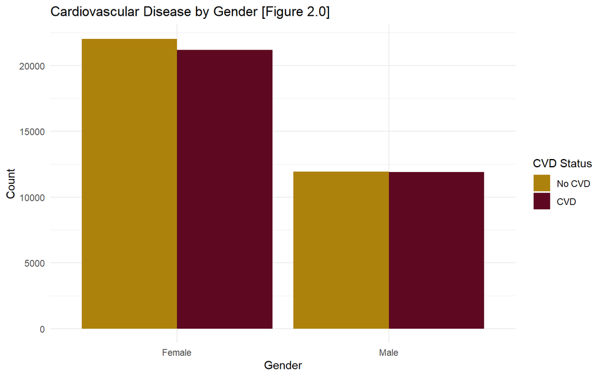

Proportion of CVD by Gender [Figure 2.1]

| Gender | CVD Status | Count | Percentage |
| --- | --- | --- | --- |
| Female | No CVD | 22036 | 51% |
| Female | CVD | 21192 | 49% |
| Male | No CVD | 11925 | 50.1% |
| Male | CVD | 11894 | 49.9% |

Figure 3.0 displays the distribution of individuals with/without CVD, separated by cholesterol level categories. Normal cholesterol levels have the largest number of individuals represented within this dataset. Additionally, 13% more individuals do not have CVD compared to those who do at a normal cholesterol level. There is a significantly smaller number of people with Above Normal and Well Above Normal cholesterol. At these levels, a greater percentage of individuals have CVD. 19% more individuals have CVD at an Above Normal level, and 52.5% at a Well Above Normal level. These visualizations suggest that within this dataset, higher cholesterol levels are associated with a higher proportion of individuals with cardiovascular disease.

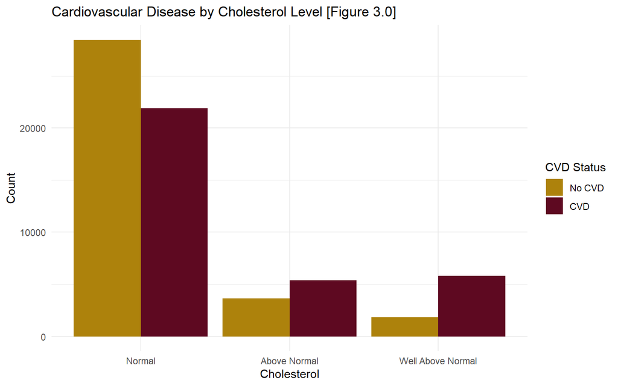

Proportion of CVD by Cholesterol [Figure 3.1]

| Cholesterol | CVD Status | Count | Percentage |
| --- | --- | --- | --- |
| Normal | No CVD | 28487 | 56.5% |
| Normal | CVD | 21910 | 43.5% |
| Above Normal | No CVD | 3654 | 40.5% |
| Above Normal | CVD | 5368 | 59.5% |
| Well Above Normal | No CVD | 1820 | 23.9% |
| Well Above Normal | CVD | 5808 | 76.1% |

Figure 4.0 displays the distribution of individuals with/without CVD, separated by glucose level categories. Normal glucose levels represent the majority of this dataset. At this level, 5% more individuals do not have CVD compared to those who do. Above normal and Well Above Normal glucose levels make up a smaller portion of the dataset. At an Above Normal level, 17% more individuals have CVD, and 22.8% at a Well Above Normal level. Within this dataset, the figures indicate that higher glucose levels are associated with a greater proportion of individuals with CVD compared to those without CVD.

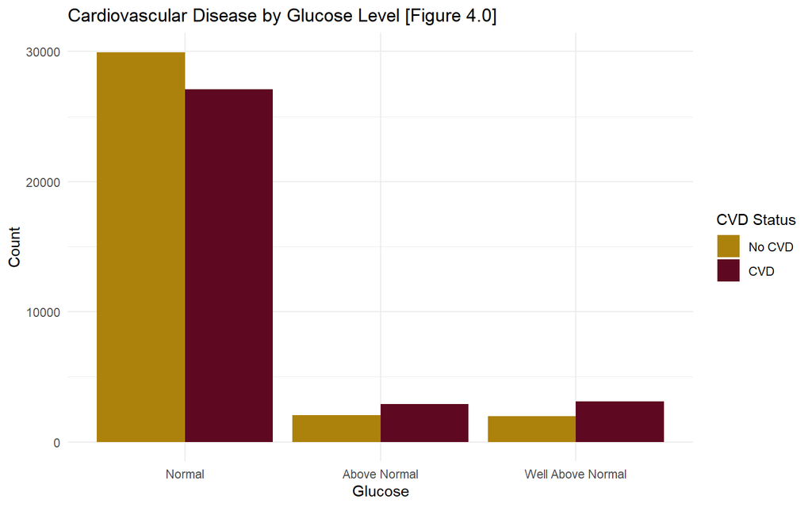

Proportion of CVD by Glucose [Figure 4.1]

| Glucose | CVD Status | Count | Percentage |
| --- | --- | --- | --- |
| Normal | No CVD | 29954 | 52.5% |
| Normal | CVD | 27078 | 47.5% |
| Above Normal | No CVD | 2044 | 41.5% |
| Above Normal | CVD | 2884 | 58.5% |
| Well Above Normal | No CVD | 1963 | 38.6% |
| Well Above Normal | CVD | 3124 | 61.4% |

Figure 5.0 shows the distribution of CVD status by age. Individuals aged 50 and below generally do not have CVD, with few who do. Between 50 to 55, the number of people who have CVD increases, with it peaking at 51 to 52. Overall, there is a similar number of people with and without CVD. In the range of individuals aged above 55, the proportion of those who have CVD compared to those who don’t increases, while the proportion of individuals who don’t have CVD begins to rapidly decline. The trend suggests that as age increases, the likelihood of CVD appearing increases.

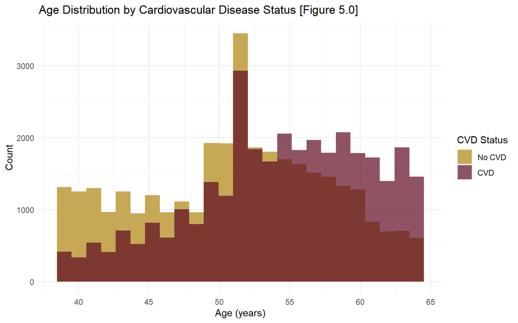

Figure 6.0 shows a scatter plot of systolic versus diastolic blood pressure by CVD status. Blood pressure values overlap between groups, but CVD cases are more concentrated at higher levels. The strong correlation between ap_hi and ap_lo supports using pulse pressure as a derived variable to capture arterial load while reducing redundancy.

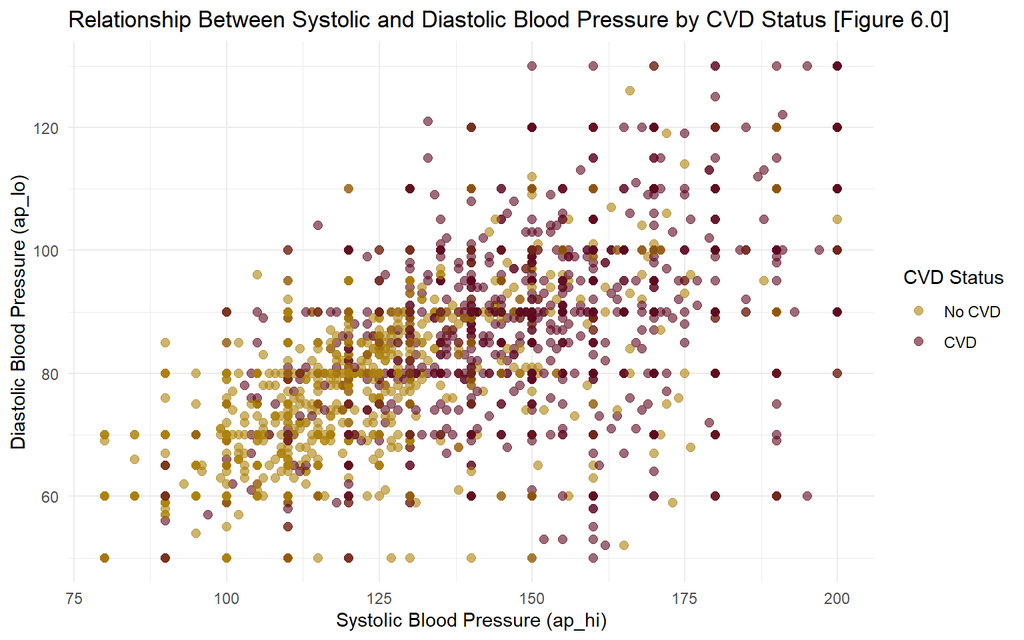

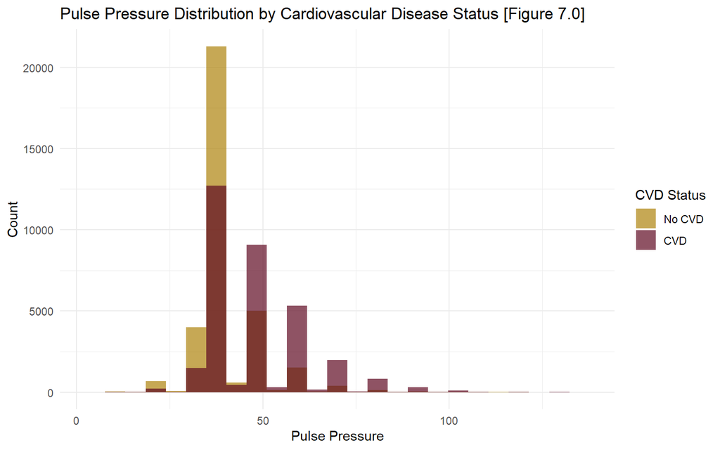

## Final Results

### Cohort characteristic table

The Cohort characteristic table shows that individuals with CVD were older and had higher pulse pressure than those without CVD. They also had higher proportions of elevated cholesterol and glucose, while gender distribution was similar between groups. These differences provide context for the subsequent logistic regression analysis.

```
##                  Stratified by cardio
##                   level             No CVD       CVD           p      test
##   n                                 33961        33086
##   age (mean (SD))                   51.19 (6.77) 54.41 (6.37)  <0.001
##   pp (mean (SD))                    41.45 (8.81) 49.23 (12.55) <0.001
##   gender (%)      Female            22036 (64.9) 21192 (64.1)  0.024
##                   Male              11925 (35.1) 11894 (35.9)
##   cholesterol (%) Normal            28487 (83.9) 21910 (66.2)  <0.001
##                   Above Normal      3654 (10.8)  5368 (16.2)
##                   Well Above Normal 1820 (5.4)   5808 (17.6)
##   gluc (%)        Normal            29954 (88.2) 27078 (81.8)  <0.001
##                   Above Normal      2044 (6.0)   2884 (8.7)
##                   Well Above Normal 1963 (5.8)   3124 (9.4)
```

### Check for collinearity

Figure 8.0 displays the VIF values for each variable. All values were close to 1, indicating minimal to no multicollinearity between the predictors. These results confirm that multicollinearity is not a concern, allowing for a reliable interpretation of the logistic regression coefficients.

Variance Inflation Factors [Figure 8.0]

| Variable | GVIF | Df | GVIF^(1/(2*Df)) |
| --- | --- | --- | --- |
| age | 1.01147 | 1 | 1.00572 |
| gender | 1.00321 | 1 | 1.00160 |
| pp | 1.00594 | 1 | 1.00297 |
| cholesterol | 1.47130 | 2 | 1.10135 |
| gluc | 1.46674 | 2 | 1.10050 |

### Coefficients Matrix

The `summary()` output provides coefficient estimates, standard errors, z-values, and p-values for each predictor in the logistic regression model (Figure 8.1). Age and pulse pressure were both associated with higher odds of CVD (p < 0.001). Cholesterol levels also showed significant effects, with the Above Normal and Well Above Normal categories increasing the likelihood of CVD, with the Well Above Normal group showing the strongest association. Glucose levels showed mixed results. The Above Normal category increased CVD odds. The Well Above Normal category was associated with reduced odds. Gender was not statistically significant (p = 0.085). Subsequently, there is no strong evidence of a gender difference impacting CVD risk within this dataset.

GLM Coefficients [Figure 8.1]

| Variable | Estimate | Std_Error | Z_value | P_value |
| --- | --- | --- | --- | --- |
| (Intercept) | -6.2006239 | 0.0792742 | -78.217475 | 0.0000000 |
| age | 0.0571831 | 0.0013074 | 43.736880 | 0.0000000 |
| genderMale | 0.0306702 | 0.0178029 | 1.722763 | 0.0849314 |
| pp | 0.0661330 | 0.0009287 | 71.212519 | 0.0000000 |
| cholesterolAbove Normal | 0.4757628 | 0.0262899 | 18.096764 | 0.0000000 |
| cholesterolWell Above Normal | 1.2824576 | 0.0349911 | 36.650970 | 0.0000000 |
| glucAbove Normal | 0.1124938 | 0.0347910 | 3.233413 | 0.0012232 |
| glucWell Above Normal | -0.3636253 | 0.0388061 | -9.370318 | 0.0000000 |

### Final Visualisations

To further illustrate these findings, an odds ratio plot was generated to visually summarise the strength and direction of each predictor’s association with CVD (Figure 8.2). This plot displays the adjusted odds ratios and their respective 95% confidence intervals. This allows for an intuitive comparison of the performance of each predictor in terms of contributing to CVD. Predictors that do not have confidence intervals crossing 1 indicate a statistically significant association. These results are consistent with the output from summary(). They reinforce the notion that gender (male) has little statistical significance, while other predictors, such as cholesterol Well Above Normal, are strong predictors.

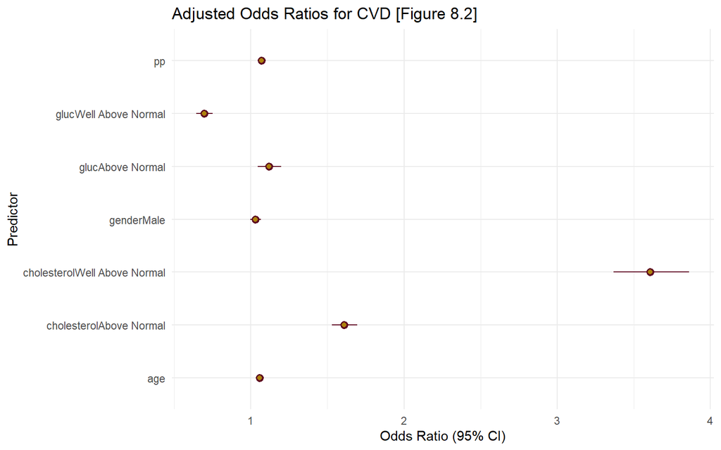

To assess the overall predictive performance of the logistic regression model, a receiver operating characteristic (ROC) curve was generated. This curve shows how well the model distinguishes between individuals with and without CVD, complementing the insights from the odds ratio plot. The ROC curve demonstrates that the model is able to perform at a relatively high level, with an area under the curve (AUC) of 0.7498. It suggests that the model has a 75% chance of correctly ranking a random individual with CVD higher than one without CVD. The model has acceptable discernibility; however, there is room for improvement.

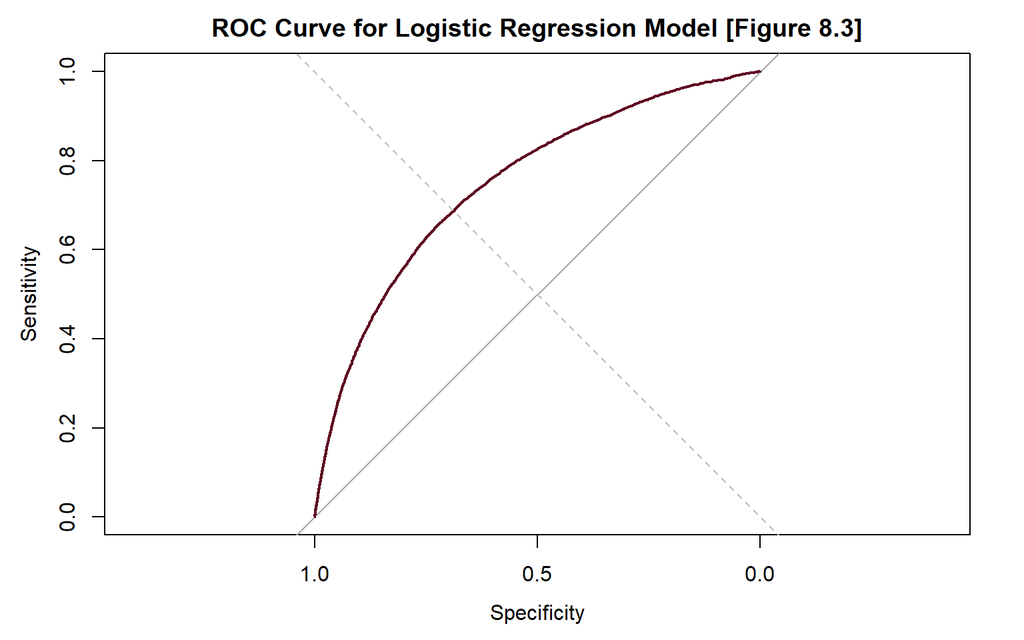

```
## Area under the curve: 0.7498
```